# Frito Lay: Employee Attrition

Jasmine Coleman

April 11, 2019

# Introduction

The DDS Analytics team has outlined our analysis for areas of focus for the talent management team at Frito Lay. We were provided with 3 data sets which included a range of demographic, performance, and/or survey information from existing employees. While we were not given the reason an employee chooses to stay with or leave the company, we were able to use the information given to build and validate an employee attrition classification model. We were also tasked with building a predictive model for an employee’s monthly income. The prediction results and final presentation of this anaylsis can be found through the links below:

#### Youtube Presentation: https://youtu.be/uSzq2ExTqFQ

#### GitHub Repo: https://github.com/jncolema/CaseStudy2DDS

# Analysis

#### Downloading and Importing the Data

```r
# getwd()

#Downloading the data
# library(downloader)
# download("https://raw.githubusercontent.com/BivinSadler/MSDS-6306-Doing-Data-Science/master/UNIT%2014/CaseStudy2-data.csv","Raw Data/Case Study 2.csv")
# download("https://raw.githubusercontent.com/BivinSadler/MSDS-6306-Doing-Data-Science/master/UNIT%2014/CaseStudy2Validation%20No%20Attrition.csv", "Raw Data/Validation Data.csv")
# list.files()

#Importing the raw case study file
EmpInfo <-read.csv("Raw Data/Case Study 2.csv", header = TRUE, sep = ",")
head(EmpInfo)
```

```
##   ID Age Attrition    BusinessTravel DailyRate             Department
## 1  1  32        No     Travel_Rarely       117                  Sales
## 2  2  40        No     Travel_Rarely      1308 Research & Development
## 3  3  35        No Travel_Frequently       200 Research & Development
## 4  4  32        No     Travel_Rarely       801                  Sales
## 5  5  24        No Travel_Frequently       567 Research & Development
## 6  6  27        No Travel_Frequently       294 Research & Development
##   DistanceFromHome Education   EducationField EmployeeCount EmployeeNumber
## 1               13         4    Life Sciences             1            859
## 2               14         3          Medical             1           1128
## 3               18         2    Life Sciences             1           1412
## 4                1         4        Marketing             1           2016
## 5                2         1 Technical Degree             1           1646
## 6               10         2    Life Sciences             1            733
##   EnvironmentSatisfaction Gender HourlyRate JobInvolvement JobLevel
```

[output cut: 48 more lines]

```r
str(EmpInfo)
```

```
## 'data.frame':    870 obs. of  37 variables:
##  $ ID                      : int  1 2 3 4 5 6 7 8 9 10 ...
##  $ Age                     : int  32 40 35 32 24 27 41 37 34 34 ...
##  $ Attrition               : Factor w/ 2 levels "No","Yes": 1 1 1 1 1 1 1 1 1 1 ...
##  $ BusinessTravel          : Factor w/ 3 levels "Non-Travel","Travel_Frequently",..: 3 3 2 3 2 2 3 3 3 2 ...
##  $ DailyRate               : int  117 1308 200 801 567 294 1283 309 1333 653 ...
##  $ Department              : Factor w/ 3 levels "Human Resources",..: 3 2 2 3 2 2 2 3 3 2 ...
##  $ DistanceFromHome        : int  13 14 18 1 2 10 5 10 10 10 ...
##  $ Education               : int  4 3 2 4 1 2 5 4 4 4 ...
##  $ EducationField          : Factor w/ 6 levels "Human Resources",..: 2 4 2 3 6 2 4 2 2 6 ...
##  $ EmployeeCount           : int  1 1 1 1 1 1 1 1 1 1 ...
##  $ EmployeeNumber          : int  859 1128 1412 2016 1646 733 1448 1105 1055 1597 ...
##  $ EnvironmentSatisfaction : int  2 3 3 3 1 4 2 4 3 4 ...
##  $ Gender                  : Factor w/ 2 levels "Female","Male": 2 2 2 1 1 2 2 1 1 2 ...
##  $ HourlyRate              : int  73 44 60 48 32 32 90 88 87 92 ...
```

[output cut: 23 more lines]

```r
#Importing Attrition Validation File
Attr_Validation <-read.csv("Raw Data/Validation Data.csv", header = TRUE, sep = ",")
str(Attr_Validation)
```

```
## 'data.frame':    300 obs. of  36 variables:
##  $ ID                      : int  1171 1172 1173 1174 1175 1176 1177 1178 1179 1180 ...
##  $ Age                     : int  35 33 26 55 29 51 52 39 31 31 ...
##  $ BusinessTravel          : Factor w/ 3 levels "Non-Travel","Travel_Frequently",..: 3 3 3 3 3 2 1 3 3 2 ...
##  $ DailyRate               : int  750 147 1330 1311 1246 1456 585 1387 1062 534 ...
##  $ Department              : Factor w/ 3 levels "Human Resources",..: 2 1 2 2 3 2 3 2 2 2 ...
##  $ DistanceFromHome        : int  28 2 21 2 19 1 29 10 24 20 ...
##  $ Education               : int  3 3 3 3 3 4 4 5 3 3 ...
##  $ EducationField          : Factor w/ 6 levels "Human Resources",..: 2 1 4 2 2 4 2 4 4 2 ...
##  $ EmployeeCount           : int  1 1 1 1 1 1 1 1 1 1 ...
##  $ EmployeeNumber          : int  1596 1207 1107 505 1497 145 2019 1618 1252 587 ...
##  $ EnvironmentSatisfaction : int  2 2 1 3 3 1 1 2 3 1 ...
##  $ Gender                  : Factor w/ 2 levels "Female","Male": 2 2 2 1 2 1 2 2 1 2 ...
##  $ HourlyRate              : int  46 99 37 97 77 30 40 76 96 66 ...
##  $ JobInvolvement          : int  4 3 3 3 2 2 3 3 2 3 ...
```

[output cut: 22 more lines]

```r
#Importing Salary Prediction File
Income_Predict <-read.csv("Raw Data/Validation No Salary.csv", header = TRUE)
str(Income_Predict)
```

```
## 'data.frame':    300 obs. of  36 variables:
##  $ ID                      : int  871 872 873 874 875 876 877 878 879 880 ...
##  $ Age                     : int  43 33 55 36 27 39 33 21 30 51 ...
##  $ Attrition               : Factor w/ 2 levels "No","Yes": 1 1 2 1 1 2 1 2 1 1 ...
##  $ BusinessTravel          : Factor w/ 3 levels "Non-Travel","Travel_Frequently",..: 2 3 3 1 3 3 1 2 2 3 ...
##  $ DailyRate               : int  1422 461 267 1351 1302 895 750 251 1312 1405 ...
##  $ Department              : Factor w/ 3 levels "Human Resources",..: 3 2 3 2 2 3 3 2 2 2 ...
##  $ DistanceFromHome        : int  2 13 13 9 19 5 22 10 23 11 ...
##  $ Education               : int  4 1 4 4 3 3 2 2 3 2 ...
##  $ EducationField          : Factor w/ 6 levels "Human Resources",..: 2 2 3 2 5 6 3 2 2 6 ...
##  $ EmployeeCount           : int  1 1 1 1 1 1 1 1 1 1 ...
##  $ EmployeeNumber          : int  1849 995 1372 1949 1619 42 160 1279 159 1367 ...
##  $ EnvironmentSatisfaction : int  1 2 1 1 4 4 3 1 1 4 ...
##  $ Gender                  : Factor w/ 2 levels "Female","Male": 2 1 2 2 2 2 2 1 2 1 ...
##  $ HourlyRate              : int  92 53 85 66 67 56 95 45 96 82 ...
```

[output cut: 22 more lines]

```r
head(Income_Predict)
```

```
##    ID Age Attrition    BusinessTravel DailyRate             Department
## 1 871  43        No Travel_Frequently      1422                  Sales
## 2 872  33        No     Travel_Rarely       461 Research & Development
## 3 873  55       Yes     Travel_Rarely       267                  Sales
## 4 874  36        No        Non-Travel      1351 Research & Development
## 5 875  27        No     Travel_Rarely      1302 Research & Development
## 6 876  39       Yes     Travel_Rarely       895                  Sales
##   DistanceFromHome Education   EducationField EmployeeCount EmployeeNumber
## 1                2         4    Life Sciences             1           1849
## 2               13         1    Life Sciences             1            995
## 3               13         4        Marketing             1           1372
## 4                9         4    Life Sciences             1           1949
## 5               19         3            Other             1           1619
## 6                5         3 Technical Degree             1             42
##   EnvironmentSatisfaction Gender HourlyRate JobInvolvement JobLevel
```

[output cut: 48 more lines]

## Initial Exploratory Plots

```r
library(tidyverse)
```

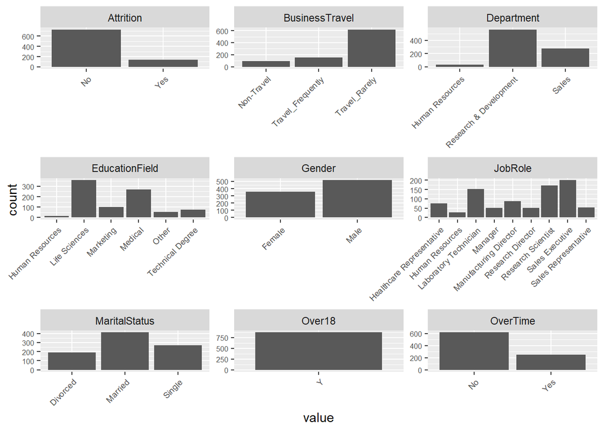

```r
library(dplyr)
library(ggplot2)
library(purrr)

#Bar chart of factor variables
EmpInfo %>%
  keep(is.factor) %>%
  gather() %>%
  ggplot(aes(value)) +
  facet_wrap(~ key, scales="free") +
  geom_bar() +
  theme(axis.text.x=element_text(size=7, angle=45, vjust=1, hjust=1),
        axis.text.y=element_text(size=6))
```

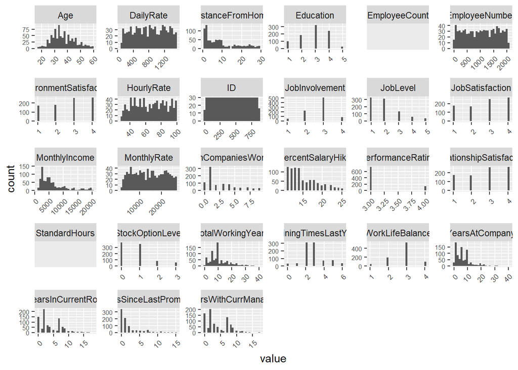

```r
#HIstogram of integer variables
EmpInfo %>%
  keep(is.integer) %>%
  gather() %>%
  ggplot(aes(value)) +
  facet_wrap(~ key, scales="free") +
  geom_histogram() +
  theme(axis.text.x=element_text(size=7, angle=45, vjust=1, hjust=1),
        axis.text.y=element_text(size=6))
```

## Cleaning Datasets

#### The following variables can be removed due to lack of variance (same answer recorded for each record)

- Over18 (Y)
- EmployeeCount (1)
- StandanrHours (80)

#### Several variables classified as integars could also be seen as categorical and will be converted to factor types

```r
##Removing Over18 variable since only 1 level of factor & EmployeeCount & StandardHours
EmpInfo2 <- EmpInfo[,-c(10, 23, 28)]
str(EmpInfo2)
```

```
## 'data.frame':    870 obs. of  34 variables:
##  $ ID                      : int  1 2 3 4 5 6 7 8 9 10 ...
##  $ Age                     : int  32 40 35 32 24 27 41 37 34 34 ...
##  $ Attrition               : Factor w/ 2 levels "No","Yes": 1 1 1 1 1 1 1 1 1 1 ...
##  $ BusinessTravel          : Factor w/ 3 levels "Non-Travel","Travel_Frequently",..: 3 3 2 3 2 2 3 3 3 2 ...
##  $ DailyRate               : int  117 1308 200 801 567 294 1283 309 1333 653 ...
##  $ Department              : Factor w/ 3 levels "Human Resources",..: 3 2 2 3 2 2 2 3 3 2 ...
##  $ DistanceFromHome        : int  13 14 18 1 2 10 5 10 10 10 ...
##  $ Education               : int  4 3 2 4 1 2 5 4 4 4 ...
##  $ EducationField          : Factor w/ 6 levels "Human Resources",..: 2 4 2 3 6 2 4 2 2 6 ...
##  $ EmployeeNumber          : int  859 1128 1412 2016 1646 733 1448 1105 1055 1597 ...
##  $ EnvironmentSatisfaction : int  2 3 3 3 1 4 2 4 3 4 ...
##  $ Gender                  : Factor w/ 2 levels "Female","Male": 2 2 2 1 1 2 2 1 1 2 ...
##  $ HourlyRate              : int  73 44 60 48 32 32 90 88 87 92 ...
##  $ JobInvolvement          : int  3 2 3 3 3 3 4 2 3 2 ...
```

[output cut: 20 more lines]

```r
#Casting Rating Variables as Factors
EmpInfo2$Education <- as.factor(EmpInfo2$Education)
EmpInfo2$EnvironmentSatisfaction <- as.factor(EmpInfo2$EnvironmentSatisfaction)
EmpInfo2$JobInvolvement <- as.factor(EmpInfo2$JobInvolvement)
EmpInfo2$JobLevel <- as.factor(EmpInfo2$JobLevel)
EmpInfo2$JobSatisfaction <- as.factor(EmpInfo2$JobSatisfaction)
EmpInfo2$PerformanceRating <- as.factor(EmpInfo2$PerformanceRating)
EmpInfo2$RelationshipSatisfaction <- as.factor(EmpInfo2$RelationshipSatisfaction)
EmpInfo2$StockOptionLevel <- as.factor(EmpInfo2$StockOptionLevel)
EmpInfo2$TrainingTimesLastYear <- as.factor(EmpInfo2$TrainingTimesLastYear)
EmpInfo2$WorkLifeBalance <- as.factor(EmpInfo2$WorkLifeBalance)

#Checking for NAs
colSums(is.na(EmpInfo2))
```

```
##                       ID                      Age                Attrition
##                        0                        0                        0
##           BusinessTravel                DailyRate               Department
##                        0                        0                        0
##         DistanceFromHome                Education           EducationField
##                        0                        0                        0
##           EmployeeNumber  EnvironmentSatisfaction                   Gender
##                        0                        0                        0
##               HourlyRate           JobInvolvement                 JobLevel
##                        0                        0                        0
##                  JobRole          JobSatisfaction            MaritalStatus
##                        0                        0                        0
##            MonthlyIncome              MonthlyRate       NumCompaniesWorked
##                        0                        0                        0
##                 OverTime        PercentSalaryHike        PerformanceRating
##                        0                        0                        0
## RelationshipSatisfaction         StockOptionLevel        TotalWorkingYears
##                        0                        0                        0
##    TrainingTimesLastYear          WorkLifeBalance           YearsAtCompany
##                        0                        0                        0
##       YearsInCurrentRole  YearsSinceLastPromotion     YearsWithCurrManager
##                        0                        0                        0
##                     Rand
##                        0
```

```r
#cleaning Validation Table
##Removing Over18 variable since only 1 level of factor & EmployeeCount & StandardHours
Attr_Validation <- Attr_Validation[,-c(9, 22, 27)]
str(EmpInfo2)
```

```
## 'data.frame':    870 obs. of  34 variables:
##  $ ID                      : int  1 2 3 4 5 6 7 8 9 10 ...
##  $ Age                     : int  32 40 35 32 24 27 41 37 34 34 ...
##  $ Attrition               : Factor w/ 2 levels "No","Yes": 1 1 1 1 1 1 1 1 1 1 ...
##  $ BusinessTravel          : Factor w/ 3 levels "Non-Travel","Travel_Frequently",..: 3 3 2 3 2 2 3 3 3 2 ...
##  $ DailyRate               : int  117 1308 200 801 567 294 1283 309 1333 653 ...
##  $ Department              : Factor w/ 3 levels "Human Resources",..: 3 2 2 3 2 2 2 3 3 2 ...
##  $ DistanceFromHome        : int  13 14 18 1 2 10 5 10 10 10 ...
##  $ Education               : Factor w/ 5 levels "1","2","3","4",..: 4 3 2 4 1 2 5 4 4 4 ...
##  $ EducationField          : Factor w/ 6 levels "Human Resources",..: 2 4 2 3 6 2 4 2 2 6 ...
##  $ EmployeeNumber          : int  859 1128 1412 2016 1646 733 1448 1105 1055 1597 ...
##  $ EnvironmentSatisfaction : Factor w/ 4 levels "1","2","3","4": 2 3 3 3 1 4 2 4 3 4 ...
##  $ Gender                  : Factor w/ 2 levels "Female","Male": 2 2 2 1 1 2 2 1 1 2 ...
##  $ HourlyRate              : int  73 44 60 48 32 32 90 88 87 92 ...
##  $ JobInvolvement          : Factor w/ 4 levels "1","2","3","4": 3 2 3 3 3 3 4 2 3 2 ...
```

[output cut: 20 more lines]

```r
#Casting Rating Variables as Factors
Attr_Validation$Education <- as.factor(Attr_Validation$Education)
Attr_Validation$EnvironmentSatisfaction <- as.factor(Attr_Validation$EnvironmentSatisfaction)
Attr_Validation$JobInvolvement <- as.factor(Attr_Validation$JobInvolvement)
Attr_Validation$JobLevel <- as.factor(Attr_Validation$JobLevel)
Attr_Validation$JobSatisfaction <- as.factor(Attr_Validation$JobSatisfaction)
Attr_Validation$PerformanceRating <- as.factor(Attr_Validation$PerformanceRating)
Attr_Validation$RelationshipSatisfaction <- as.factor(Attr_Validation$RelationshipSatisfaction)
Attr_Validation$StockOptionLevel <- as.factor(Attr_Validation$StockOptionLevel)
Attr_Validation$TrainingTimesLastYear <- as.factor(Attr_Validation$TrainingTimesLastYear)
Attr_Validation$WorkLifeBalance <- as.factor(Attr_Validation$WorkLifeBalance)

#cleaning Prediction File
##Removing Over18 variable since only 1 level of factor & EmployeeCount & StandardHours
Income_Predict <- Income_Predict[,-c(10, 22, 27)]
str(EmpInfo2)
```

```
## 'data.frame':    870 obs. of  34 variables:
##  $ ID                      : int  1 2 3 4 5 6 7 8 9 10 ...
##  $ Age                     : int  32 40 35 32 24 27 41 37 34 34 ...
##  $ Attrition               : Factor w/ 2 levels "No","Yes": 1 1 1 1 1 1 1 1 1 1 ...
##  $ BusinessTravel          : Factor w/ 3 levels "Non-Travel","Travel_Frequently",..: 3 3 2 3 2 2 3 3 3 2 ...
##  $ DailyRate               : int  117 1308 200 801 567 294 1283 309 1333 653 ...
##  $ Department              : Factor w/ 3 levels "Human Resources",..: 3 2 2 3 2 2 2 3 3 2 ...
##  $ DistanceFromHome        : int  13 14 18 1 2 10 5 10 10 10 ...
##  $ Education               : Factor w/ 5 levels "1","2","3","4",..: 4 3 2 4 1 2 5 4 4 4 ...
##  $ EducationField          : Factor w/ 6 levels "Human Resources",..: 2 4 2 3 6 2 4 2 2 6 ...
##  $ EmployeeNumber          : int  859 1128 1412 2016 1646 733 1448 1105 1055 1597 ...
##  $ EnvironmentSatisfaction : Factor w/ 4 levels "1","2","3","4": 2 3 3 3 1 4 2 4 3 4 ...
##  $ Gender                  : Factor w/ 2 levels "Female","Male": 2 2 2 1 1 2 2 1 1 2 ...
##  $ HourlyRate              : int  73 44 60 48 32 32 90 88 87 92 ...
##  $ JobInvolvement          : Factor w/ 4 levels "1","2","3","4": 3 2 3 3 3 3 4 2 3 2 ...
```

[output cut: 20 more lines]

```r
#Casting Rating Variables as Factors
Income_Predict$Education <- as.factor(Income_Predict$Education)
Income_Predict$EnvironmentSatisfaction <- as.factor(Income_Predict$EnvironmentSatisfaction)
Income_Predict$JobInvolvement <- as.factor(Income_Predict$JobInvolvement)
Income_Predict$JobLevel <- as.factor(Income_Predict$JobLevel)
Income_Predict$JobSatisfaction <- as.factor(Income_Predict$JobSatisfaction)
Income_Predict$PerformanceRating <- as.factor(Income_Predict$PerformanceRating)
Income_Predict$RelationshipSatisfaction <- as.factor(Income_Predict$RelationshipSatisfaction)
Income_Predict$StockOptionLevel <- as.factor(Income_Predict$StockOptionLevel)
Income_Predict$TrainingTimesLastYear <- as.factor(Income_Predict$TrainingTimesLastYear)
Income_Predict$WorkLifeBalance <- as.factor(Income_Predict$WorkLifeBalance)
```

## Correlation Plots

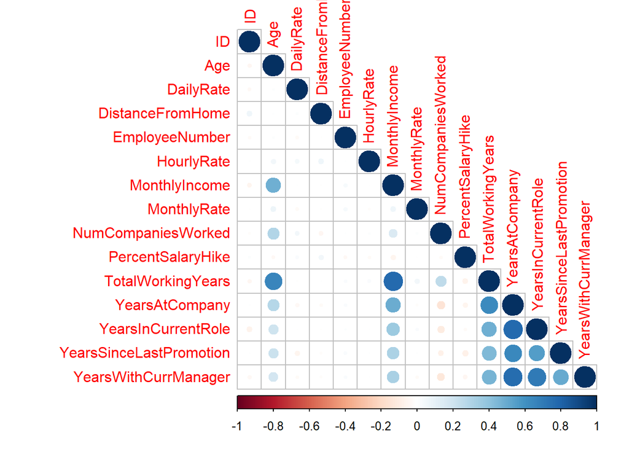

```r
#Correlation Plots
library(corrplot)
#Only Integer Variables
EmpCorrelations <- cor(EmpInfo2 %>% keep(is.integer))
corrplot(EmpCorrelations, type = "lower", diag = TRUE)
```

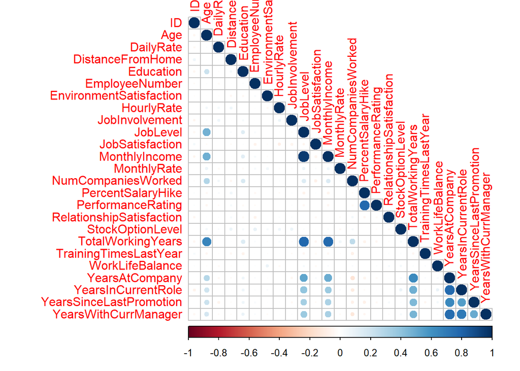

```r
#All Variables
EmpCorrelationsAll <- cor(EmpInfo[,-c(10, 23, 28)] %>% keep(is.integer))
corrplot(EmpCorrelationsAll, type = "lower", diag = TRUE)
```

## Attrition Frequencies

```r
#Creating Attrition Proportion Tables
TotalAttr <- table(EmpInfo2$Attrition)
BusTravAttr <- table(EmpInfo2$BusinessTravel,EmpInfo2$Attrition)
DeptAttr <- table(EmpInfo2$Department,EmpInfo2$Attrition)
EduFieldAttr <- table(EmpInfo2$EducationField,EmpInfo2$Attrition)
GenderAttr <- table(EmpInfo2$Gender,EmpInfo2$Attrition)
RoleAttr <- table(EmpInfo2$JobRole,EmpInfo2$Attrition)
MaritalAttr <- table(EmpInfo2$MaritalStatus,EmpInfo2$Attrition)
OverTimeAttr <- table(EmpInfo2$OverTime,EmpInfo2$Attrition)

EducationAttr <- table(EmpInfo2$Education,EmpInfo2$Attrition)
EnvirSatAttr <- table(EmpInfo2$EnvironmentSatisfaction,EmpInfo2$Attrition)
JobInvAttr <- table(EmpInfo2$JobInvolvement,EmpInfo2$Attrition)
JobLevAttr <- table(EmpInfo2$JobLevel,EmpInfo2$Attrition)
JobSatAttr <- table(EmpInfo2$JobSatisfaction,EmpInfo2$Attrition)
PerRatAttr <- table(EmpInfo2$PerformanceRating,EmpInfo2$Attrition)
RelSatAttr <- table(EmpInfo2$RelationshipSatisfaction,EmpInfo2$Attrition)
StockAttr <- table(EmpInfo2$StockOptionLevel,EmpInfo2$Attrition)
TrainTimeAttr <- table(EmpInfo2$TrainingTimesLastYear,EmpInfo2$Attrition)
WorkLifeAttr <- table(EmpInfo2$WorkLifeBalance,EmpInfo2$Attrition)

#Getting Percentages
TotalAttr_Prop <- prop.table(TotalAttr)
BusTravAttr_Prop <- data.frame(prop.table(BusTravAttr, 1))
DeptAttr_Prop <- data.frame(prop.table(DeptAttr, 1) )
EduFieldAttrAttr_Prop <- data.frame(prop.table(EduFieldAttr, 1) )
GenderAttr_Prop <- data.frame(prop.table(GenderAttr, 1))
RoleAttr_Prop <- data.frame(prop.table(RoleAttr, 1) )
MaritalAttr_Prop <- data.frame(prop.table(MaritalAttr, 1))
OverTimeAttr_Prop <- data.frame(prop.table(OverTimeAttr, 1))

EducationAttr_Prop <- data.frame(prop.table(EducationAttr, 1))
EnvirSatAttr_Prop <- data.frame(prop.table(EnvirSatAttr, 1))
JobInvAttr_Prop <- data.frame(prop.table(JobInvAttr, 1))
JobLevAttr_Prop <- data.frame(prop.table(JobLevAttr, 1))
JobSatAttr_Prop <- data.frame(prop.table(JobSatAttr, 1))
PerRatAttr_Prop <- data.frame(prop.table(PerRatAttr, 1))
RelSatAttr_Prop <- data.frame(prop.table(RelSatAttr, 1))
StockAttr_Prop <- data.frame(prop.table(StockAttr, 1))
TrainTimeAttr_Prop <- data.frame(prop.table(TrainTimeAttr, 1))
WorkLifeAttr_Prop <- data.frame(prop.table(WorkLifeAttr, 1))

#Testing significance of difference in attrition between levels of each variable
prop.test(BusTravAttr, correct=FALSE) #sig
```

```
##
##  3-sample test for equality of proportions without continuity
##  correction
##
## data:  BusTravAttr
## X-squared = 5.9945, df = 2, p-value = 0.04993
## alternative hypothesis: two.sided
## sample estimates:
##    prop 1    prop 2    prop 3
## 0.8829787 0.7784810 0.8478964
```

```r
prop.test(DeptAttr, correct=FALSE) #sig
```

```
##
##  3-sample test for equality of proportions without continuity
##  correction
##
## data:  DeptAttr
## X-squared = 9.329, df = 2, p-value = 0.009424
## alternative hypothesis: two.sided
## sample estimates:
##    prop 1    prop 2    prop 3
## 0.8285714 0.8665480 0.7838828
```

```r
prop.test(EduFieldAttr, correct=FALSE) ##insig
```

```
##
##  6-sample test for equality of proportions without continuity
##  correction
##
## data:  EduFieldAttr
## X-squared = 6.4114, df = 5, p-value = 0.2682
## alternative hypothesis: two.sided
## sample estimates:
##    prop 1    prop 2    prop 3    prop 4    prop 5    prop 6
## 0.7333333 0.8519553 0.8000000 0.8629630 0.8269231 0.7733333
```

```r
prop.test(GenderAttr, correct=FALSE) #insig
```

```
##
##  2-sample test for equality of proportions without continuity
##  correction
##
## data:  GenderAttr
## X-squared = 0.55469, df = 1, p-value = 0.4564
## alternative hypothesis: two.sided
## 95 percent confidence interval:
##  -0.03035720  0.06813147
## sample estimates:
##    prop 1    prop 2
## 0.8502825 0.8313953
```

```r
prop.test(RoleAttr, correct=FALSE) ##sig
```

```
##
##  9-sample test for equality of proportions without continuity
##  correction
##
## data:  RoleAttr
## X-squared = 60.543, df = 8, p-value = 3.647e-10
## alternative hypothesis: two.sided
## sample estimates:
##    prop 1    prop 2    prop 3    prop 4    prop 5    prop 6    prop 7
## 0.8947368 0.7777778 0.8039216 0.9215686 0.9770115 0.9803922 0.8139535
##    prop 8    prop 9
## 0.8350000 0.5471698
```

```r
prop.test(MaritalAttr, correct=FALSE) #sig
```

```
##
##  3-sample test for equality of proportions without continuity
##  correction
##
## data:  MaritalAttr
## X-squared = 34.406, df = 2, p-value = 3.379e-08
## alternative hypothesis: two.sided
## sample estimates:
##    prop 1    prop 2    prop 3
## 0.9371728 0.8585366 0.7397770
```

```r
prop.test(OverTimeAttr, correct=FALSE) #sig
```

```
##
##  2-sample test for equality of proportions without continuity
##  correction
##
## data:  OverTimeAttr
## X-squared = 64.383, df = 1, p-value = 1.024e-15
## alternative hypothesis: two.sided
## 95 percent confidence interval:
##  0.1583412 0.2824046
## sample estimates:
##    prop 1    prop 2
## 0.9029126 0.6825397
```

```r
prop.test(EducationAttr, correct=FALSE) ##insig
```

```
##
##  5-sample test for equality of proportions without continuity
##  correction
##
## data:  EducationAttr
## X-squared = 2.6143, df = 4, p-value = 0.6243
## alternative hypothesis: two.sided
## sample estimates:
##    prop 1    prop 2    prop 3    prop 4    prop 5
## 0.8163265 0.8241758 0.8302469 0.8666667 0.8846154
```

```r
prop.test(EnvirSatAttr, correct=FALSE) #sig
```

```
##
##  4-sample test for equality of proportions without continuity
##  correction
##
## data:  EnvirSatAttr
## X-squared = 11.231, df = 3, p-value = 0.01054
## alternative hypothesis: two.sided
## sample estimates:
##    prop 1    prop 2    prop 3    prop 4
## 0.7558140 0.8651685 0.8643411 0.8511450
```

```r
prop.test(JobInvAttr, correct=FALSE) #sig
```

```
##
##  4-sample test for equality of proportions without continuity
##  correction
##
## data:  JobInvAttr
## X-squared = 41.465, df = 3, p-value = 5.211e-09
## alternative hypothesis: two.sided
## sample estimates:
##    prop 1    prop 2    prop 3    prop 4
## 0.5319149 0.8070175 0.8696498 0.9135802
```

```r
prop.test(JobLevAttr, correct=FALSE) #sig
```

```
##
##  5-sample test for equality of proportions without continuity
##  correction
##
## data:  JobLevAttr
## X-squared = 41.533, df = 4, p-value = 2.085e-08
## alternative hypothesis: two.sided
## sample estimates:
##    prop 1    prop 2    prop 3    prop 4    prop 5
## 0.7386018 0.9038462 0.8712121 0.9500000 0.8918919
```

```r
prop.test(JobSatAttr, correct=FALSE) #sig
```

```
##
##  4-sample test for equality of proportions without continuity
##  correction
##
## data:  JobSatAttr
## X-squared = 11.109, df = 3, p-value = 0.01115
## alternative hypothesis: two.sided
## sample estimates:
##    prop 1    prop 2    prop 3    prop 4
## 0.7877095 0.8132530 0.8307087 0.8966790
```

```r
prop.test(PerRatAttr, correct=FALSE) #insig
```

```
##
##  2-sample test for equality of proportions without continuity
##  correction
##
## data:  PerRatAttr
## X-squared = 0.20456, df = 1, p-value = 0.6511
## alternative hypothesis: two.sided
## 95 percent confidence interval:
##  -0.05416290  0.08557457
## sample estimates:
##    prop 1    prop 2
## 0.8414634 0.8257576
```

```r
prop.test(RelSatAttr, correct=FALSE) #insig
```

```
##
##  4-sample test for equality of proportions without continuity
##  correction
##
## data:  RelSatAttr
## X-squared = 3.1253, df = 3, p-value = 0.3727
## alternative hypothesis: two.sided
## sample estimates:
##    prop 1    prop 2    prop 3    prop 4
## 0.7988506 0.8421053 0.8620690 0.8409091
```

```r
prop.test(StockAttr, correct=FALSE) #sig
```

```
##
##  4-sample test for equality of proportions without continuity
##  correction
##
## data:  StockAttr
## X-squared = 56.245, df = 3, p-value = 3.724e-12
## alternative hypothesis: two.sided
## sample estimates:
##    prop 1    prop 2    prop 3    prop 4
## 0.7414248 0.9239437 0.9629630 0.7818182
```

```r
prop.test(TrainTimeAttr, correct=FALSE) ##insig
```

```
##
##  7-sample test for equality of proportions without continuity
##  correction
##
## data:  TrainTimeAttr
## X-squared = 10.132, df = 6, p-value = 0.1192
## alternative hypothesis: two.sided
## sample estimates:
##    prop 1    prop 2    prop 3    prop 4    prop 5    prop 6    prop 7
## 0.7333333 0.8717949 0.8155340 0.8603896 0.7808219 0.9066667 0.8888889
```

```r
prop.test(WorkLifeAttr, correct=FALSE) #sig
```

```
##
##  4-sample test for equality of proportions without continuity
##  correction
##
## data:  WorkLifeAttr
## X-squared = 14.325, df = 3, p-value = 0.002495
## alternative hypothesis: two.sided
## sample estimates:
##    prop 1    prop 2    prop 3    prop 4
## 0.6458333 0.8437500 0.8496241 0.8673469
```

```r
prop.test(table(EmpInfo2$Age, EmpInfo2$Attrition), correct=FALSE) ##sig
```

```
##
##  43-sample test for equality of proportions without continuity
##  correction
##
## data:  table(EmpInfo2$Age, EmpInfo2$Attrition)
## X-squared = 79.178, df = 42, p-value = 0.0004559
## alternative hypothesis: two.sided
## sample estimates:
##    prop 1    prop 2    prop 3    prop 4    prop 5    prop 6    prop 7
## 0.3333333 0.4285714 0.2500000 0.6666667 0.6250000 1.0000000 0.7647059
##    prop 8    prop 9   prop 10   prop 11   prop 12   prop 13   prop 14
## 0.7647059 0.8000000 0.9090909 0.6666667 0.7073171 0.8648649 0.7435897
##   prop 15   prop 16   prop 17   prop 18   prop 19   prop 20   prop 21
## 0.8157895 0.8000000 0.8947368 0.8541667 0.8809524 0.9032258 0.9722222
##   prop 22   prop 23   prop 24   prop 25   prop 26   prop 27   prop 28
## 0.8333333 0.8965517 0.8400000 0.9655172 0.9000000 0.8888889 0.9230769
##   prop 29   prop 30   prop 31   prop 32   prop 33   prop 34   prop 35
## 0.9090909 0.8947368 0.8461538 0.9285714 0.8571429 0.9090909 0.7000000
##   prop 36   prop 37   prop 38   prop 39   prop 40   prop 41   prop 42
## 0.8571429 1.0000000 0.9166667 0.8000000 1.0000000 0.5714286 1.0000000
##   prop 43
## 1.0000000
```

```r
prop.test(table(EmpInfo2$DailyRate, EmpInfo2$Attrition), correct=FALSE) ##insig
```

[output not shown]

[output cut: 133 more lines]

[output not shown]

```r
prop.test(table(EmpInfo2$DistanceFromHome, EmpInfo2$Attrition), correct=FALSE) ##sig
```

```
##
##  29-sample test for equality of proportions without continuity
##  correction
##
## data:  table(EmpInfo2$DistanceFromHome, EmpInfo2$Attrition)
## X-squared = 42.255, df = 28, p-value = 0.04102
## alternative hypothesis: two.sided
## sample estimates:
##    prop 1    prop 2    prop 3    prop 4    prop 5    prop 6    prop 7
## 0.8482143 0.8721805 0.8222222 0.8863636 0.8484848 0.8918919 0.8800000
##    prop 8    prop 9   prop 10   prop 11   prop 12   prop 13   prop 14
## 0.9166667 0.7800000 0.8958333 0.8750000 0.8181818 0.6363636 0.7333333
##   prop 15   prop 16   prop 17   prop 18   prop 19   prop 20   prop 21
## 0.8461538 0.8000000 0.8571429 0.8750000 0.8000000 0.7500000 0.8571429
##   prop 22   prop 23   prop 24   prop 25   prop 26   prop 27   prop 28
## 0.5833333 0.7857143 0.5000000 0.8750000 0.9285714 0.8750000 0.9230769
##   prop 29
## 0.7142857
```

```r
prop.test(table(EmpInfo2$HourlyRate, EmpInfo2$Attrition), correct=FALSE) ##insig
```

```
##
##  71-sample test for equality of proportions without continuity
##  correction
##
## data:  table(EmpInfo2$HourlyRate, EmpInfo2$Attrition)
## X-squared = 81.419, df = 70, p-value = 0.1653
## alternative hypothesis: two.sided
## sample estimates:
##    prop 1    prop 2    prop 3    prop 4    prop 5    prop 6    prop 7
## 1.0000000 1.0000000 0.9166667 0.8333333 0.5714286 1.0000000 0.6666667
##    prop 8    prop 9   prop 10   prop 11   prop 12   prop 13   prop 14
## 0.8888889 0.6250000 0.8000000 0.8333333 0.9090909 1.0000000 0.9411765
##   prop 15   prop 16   prop 17   prop 18   prop 19   prop 20   prop 21
## 1.0000000 0.8666667 0.7058824 0.9090909 0.9333333 0.8333333 0.6250000
##   prop 22   prop 23   prop 24   prop 25   prop 26   prop 27   prop 28
## 0.8333333 0.8750000 0.8571429 0.7777778 0.8888889 0.9375000 0.8333333
##   prop 29   prop 30   prop 31   prop 32   prop 33   prop 34   prop 35
## 0.7500000 1.0000000 0.9333333 0.8181818 0.8333333 1.0000000 0.7500000
##   prop 36   prop 37   prop 38   prop 39   prop 40   prop 41   prop 42
## 0.8571429 0.5833333 0.8333333 0.8181818 0.7142857 0.5384615 0.8181818
##   prop 43   prop 44   prop 45   prop 46   prop 47   prop 48   prop 49
## 0.7894737 0.7142857 1.0000000 0.9166667 0.9285714 0.8000000 0.9166667
##   prop 50   prop 51   prop 52   prop 53   prop 54   prop 55   prop 56
## 0.7222222 0.9285714 0.9285714 0.8461538 1.0000000 0.7058824 0.6363636
##   prop 57   prop 58   prop 59   prop 60   prop 61   prop 62   prop 63
## 0.8333333 1.0000000 0.8333333 0.7142857 0.9000000 1.0000000 0.8125000
##   prop 64   prop 65   prop 66   prop 67   prop 68   prop 69   prop 70
## 1.0000000 0.7857143 0.8125000 0.7692308 0.7272727 0.9285714 0.7000000
##   prop 71
## 0.7692308
```

```r
prop.test(table(EmpInfo2$MonthlyRate, EmpInfo2$Attrition), correct=FALSE) ##insig
```

[output not shown]

[output cut: 197 more lines]

[output not shown]

```r
prop.test(table(EmpInfo2$MonthlyIncome, EmpInfo2$Attrition), correct=FALSE) ##insig
```

[output not shown]

[output cut: 189 more lines]

[output not shown]

```r
prop.test(table(EmpInfo2$TotalWorkingYears, EmpInfo2$Attrition), correct=FALSE) ##sig
```

```
##
##  39-sample test for equality of proportions without continuity
##  correction
##
## data:  table(EmpInfo2$TotalWorkingYears, EmpInfo2$Attrition)
## X-squared = 74.121, df = 38, p-value = 0.0004072
## alternative hypothesis: two.sided
## sample estimates:
##    prop 1    prop 2    prop 3    prop 4    prop 5    prop 6    prop 7
## 0.2857143 0.5833333 0.6500000 0.7407407 0.8000000 0.7755102 0.8194444
##    prop 8    prop 9   prop 10   prop 11   prop 12   prop 13   prop 14
## 0.8085106 0.8688525 0.9137931 0.8863636 0.8500000 0.9130435 0.8800000
##   prop 15   prop 16   prop 17   prop 18   prop 19   prop 20   prop 21
## 0.8636364 0.8965517 0.8750000 0.8823529 0.8461538 0.9230769 0.9411765
##   prop 22   prop 23   prop 24   prop 25   prop 26   prop 27   prop 28
## 0.9411765 0.9285714 0.8571429 0.8888889 0.8333333 0.8750000 1.0000000
##   prop 29   prop 30   prop 31   prop 32   prop 33   prop 34   prop 35
## 1.0000000 1.0000000 1.0000000 0.8333333 1.0000000 0.5000000 1.0000000
##   prop 36   prop 37   prop 38   prop 39
## 1.0000000 1.0000000 1.0000000 0.0000000
```

```r
prop.test(table(EmpInfo2$YearsAtCompany, EmpInfo2$Attrition), correct=FALSE) ##sig
```

```
##
##  32-sample test for equality of proportions without continuity
##  correction
##
## data:  table(EmpInfo2$YearsAtCompany, EmpInfo2$Attrition)
## X-squared = 69.893, df = 31, p-value = 7.894e-05
## alternative hypothesis: two.sided
## sample estimates:
##    prop 1    prop 2    prop 3    prop 4    prop 5    prop 6    prop 7
## 0.6071429 0.6728972 0.7532468 0.8823529 0.8148148 0.8857143 0.9318182
##    prop 8    prop 9   prop 10   prop 11   prop 12   prop 13   prop 14
## 0.9047619 0.9000000 0.9038462 0.8571429 0.8823529 1.0000000 0.9000000
##   prop 15   prop 16   prop 17   prop 18   prop 19   prop 20   prop 21
## 0.8571429 0.9090909 0.8333333 0.8000000 0.8750000 1.0000000 1.0000000
##   prop 22   prop 23   prop 24   prop 25   prop 26   prop 27   prop 28
## 1.0000000 0.9166667 0.0000000 0.7500000 1.0000000 1.0000000 1.0000000
##   prop 29   prop 30   prop 31   prop 32
## 1.0000000 0.6666667 1.0000000 0.0000000
```

```r
prop.test(table(EmpInfo2$YearsInCurrentRole, EmpInfo2$Attrition), correct=FALSE) ##sig
```

```
##
##  19-sample test for equality of proportions without continuity
##  correction
##
## data:  table(EmpInfo2$YearsInCurrentRole, EmpInfo2$Attrition)
## X-squared = 43.028, df = 18, p-value = 0.0007929
## alternative hypothesis: two.sided
## sample estimates:
##    prop 1    prop 2    prop 3    prop 4    prop 5    prop 6    prop 7
## 0.6953642 0.8421053 0.8161435 0.8823529 0.8867925 0.9615385 1.0000000
##    prop 8    prop 9   prop 10   prop 11   prop 12   prop 13   prop 14
## 0.8602941 0.9285714 0.9250000 0.8571429 1.0000000 0.8571429 0.8888889
##   prop 15   prop 16   prop 17   prop 18   prop 19
## 0.8571429 0.6666667 1.0000000 1.0000000 1.0000000
```

```r
prop.test(table(EmpInfo2$YearsSinceLastPromotion, EmpInfo2$Attrition), correct=FALSE) ##insig
```

```
##
##  16-sample test for equality of proportions without continuity
##  correction
##
## data:  table(EmpInfo2$YearsSinceLastPromotion, EmpInfo2$Attrition)
## X-squared = 21.239, df = 15, p-value = 0.1294
## alternative hypothesis: two.sided
## sample estimates:
##    prop 1    prop 2    prop 3    prop 4    prop 5    prop 6    prop 7
## 0.8157895 0.8785047 0.7978723 0.8125000 0.9375000 0.9666667 0.7826087
##    prop 8    prop 9   prop 10   prop 11   prop 12   prop 13   prop 14
## 0.8048780 1.0000000 0.6666667 0.7500000 0.8571429 1.0000000 1.0000000
##   prop 15   prop 16
## 0.8000000 0.6250000
```

#### A Chi-Squared test was used to compare the attrition rate between levels of each variable and test for significances

#### There does not appear to be a significant difference in the attrition rate for the following variables:

- Education Field or Level
- Gender
- Performance Rating
- Relationship Satisfaction
- Training Time
- Daily Rate, Hourly Rate, Monthly Income
- Years Since Last Promotion

## Plotting Attrition Rate Percentage (where Attrition was significant)

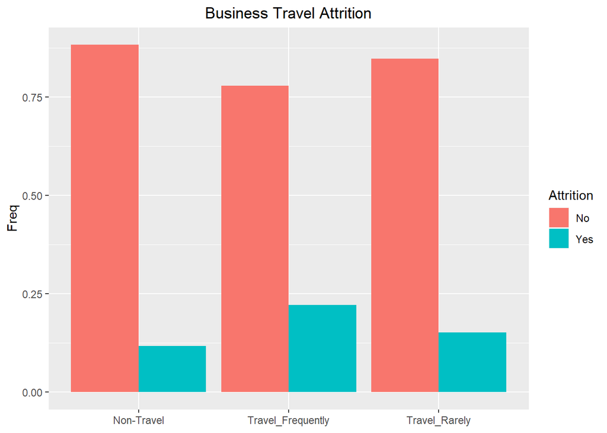

```r
#Plotting Attrition Perctages for Categorical Variables
ggplot(data=BusTravAttr_Prop, aes(x=Var1, y=Freq, fill=Var2)) +
  geom_bar(stat="identity", position=position_dodge()) +
  theme (axis.title.x = element_blank(), plot.title = element_text(hjust = 0.5)) +
  labs(fill = "Attrition") +
  ggtitle("Business Travel Attrition")
```

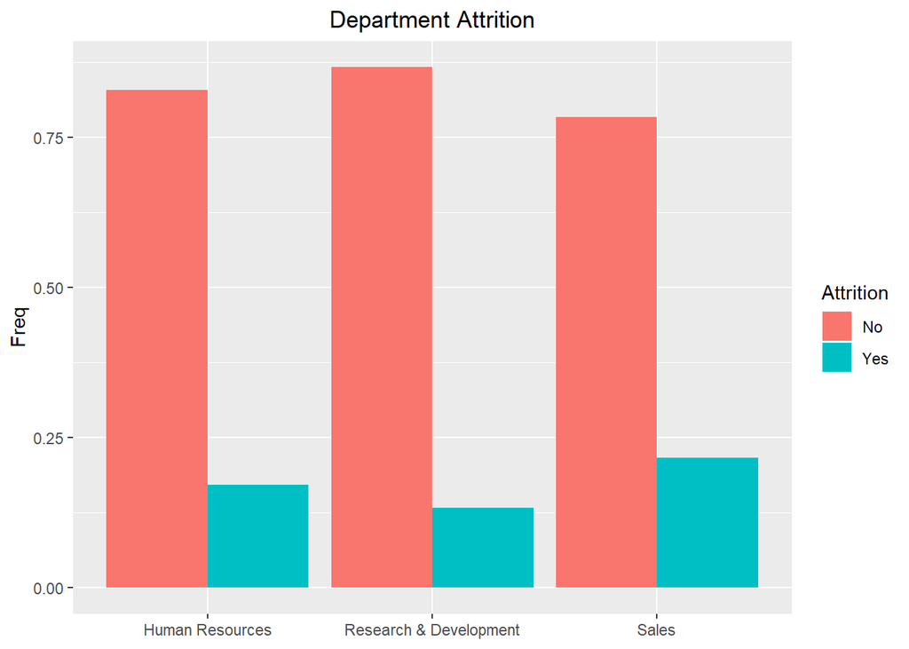

```r
ggplot(data=DeptAttr_Prop, aes(x=Var1, y=Freq, fill=Var2)) +
  geom_bar(stat="identity", position=position_dodge()) +
  theme (axis.title.x = element_blank(), plot.title = element_text(hjust = 0.5)) +
  labs(fill = "Attrition") +
  ggtitle("Department Attrition")
```

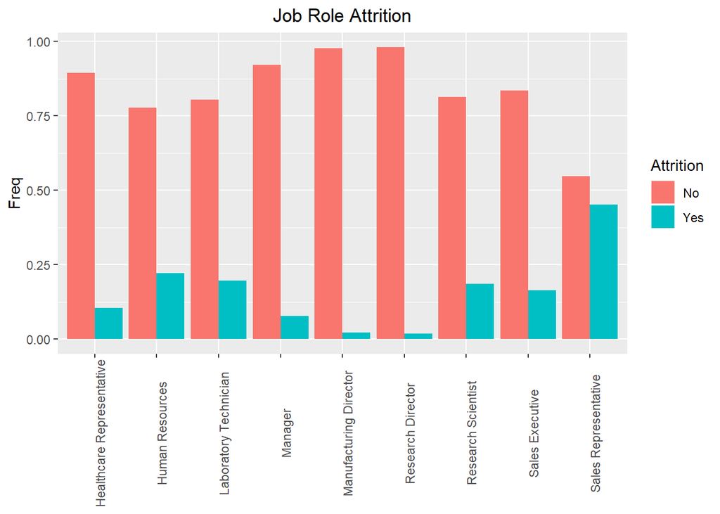

```r
ggplot(data=RoleAttr_Prop, aes(x=Var1, y=Freq, fill=Var2)) +
  geom_bar(stat="identity", position=position_dodge()) +
  theme (axis.title.x = element_blank(), plot.title = element_text(hjust = 0.5)) +
  labs(fill = "Attrition") +
  ggtitle("Job Role Attrition") +
  theme(axis.text.x=element_text(angle=90))
```

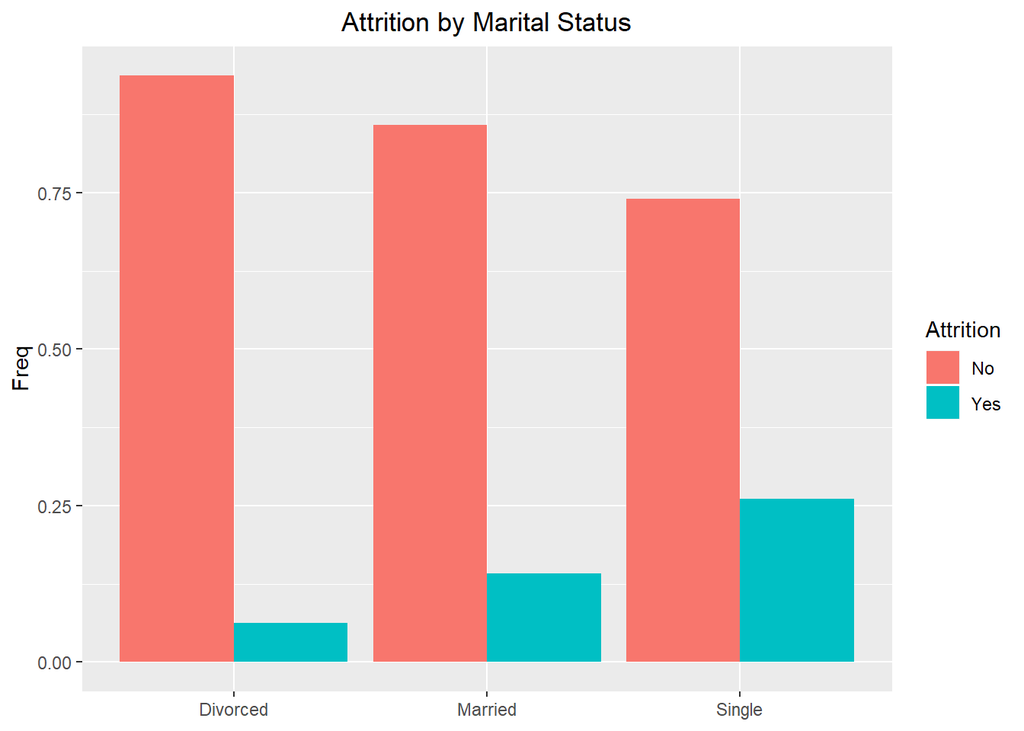

```r
ggplot(data=MaritalAttr_Prop, aes(x=Var1, y=Freq, fill=Var2)) +
  geom_bar(stat="identity", position=position_dodge()) +
  theme (axis.title.x = element_blank(), plot.title = element_text(hjust = 0.5)) +
  labs(fill = "Attrition") +
  ggtitle("Attrition by Marital Status")
```

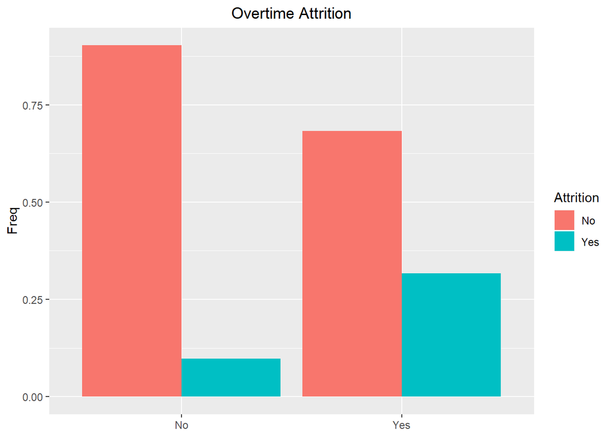

```r
ggplot(data=OverTimeAttr_Prop, aes(x=Var1, y=Freq, fill=Var2)) +
  geom_bar(stat="identity", position=position_dodge()) +
  theme (axis.title.x = element_blank(), plot.title = element_text(hjust = 0.5)) +
  labs(fill = "Attrition") +
  ggtitle("Overtime Attrition")
```

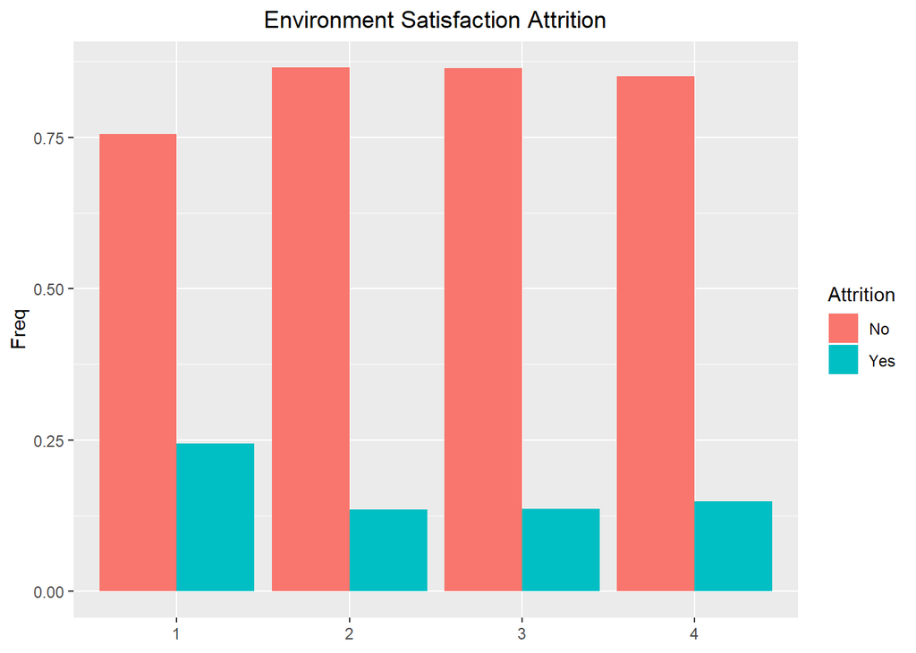

```r
ggplot(data=EnvirSatAttr_Prop, aes(x=Var1, y=Freq, fill=Var2)) +
  geom_bar(stat="identity", position=position_dodge()) +
  theme (axis.title.x = element_blank(), plot.title = element_text(hjust = 0.5)) +
  labs(fill = "Attrition") +
  ggtitle("Environment Satisfaction Attrition")
```

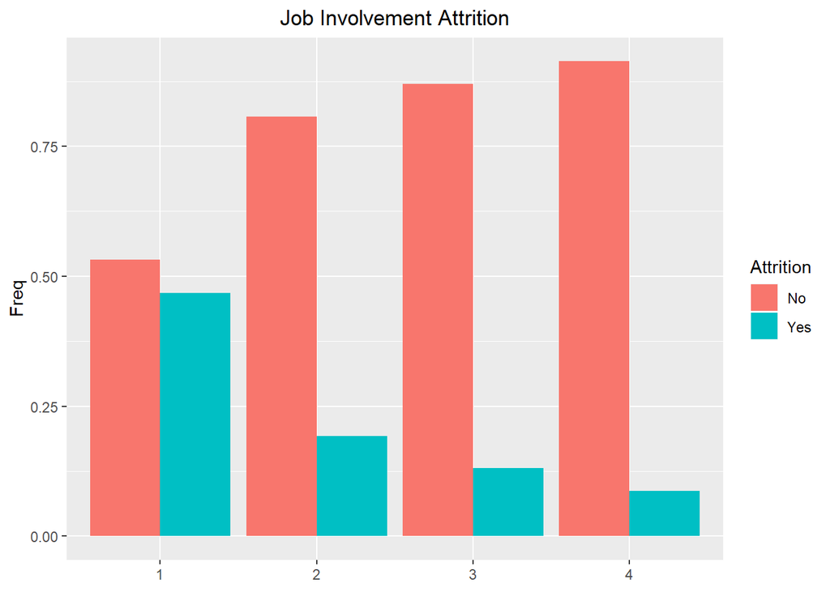

```r
ggplot(data=JobInvAttr_Prop, aes(x=Var1, y=Freq, fill=Var2)) +
  geom_bar(stat="identity", position=position_dodge()) +
  theme (axis.title.x = element_blank(), plot.title = element_text(hjust = 0.5)) +
  labs(fill = "Attrition") +
  ggtitle("Job Involvement Attrition")
```

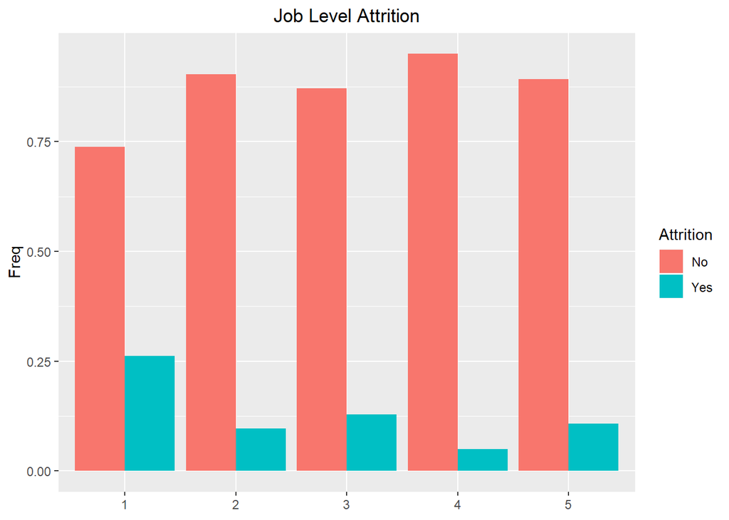

```r
ggplot(data=JobLevAttr_Prop, aes(x=Var1, y=Freq, fill=Var2)) +
  geom_bar(stat="identity", position=position_dodge()) +
  theme (axis.title.x = element_blank(), plot.title = element_text(hjust = 0.5)) +
  labs(fill = "Attrition") +
  ggtitle("Job Level Attrition")
```

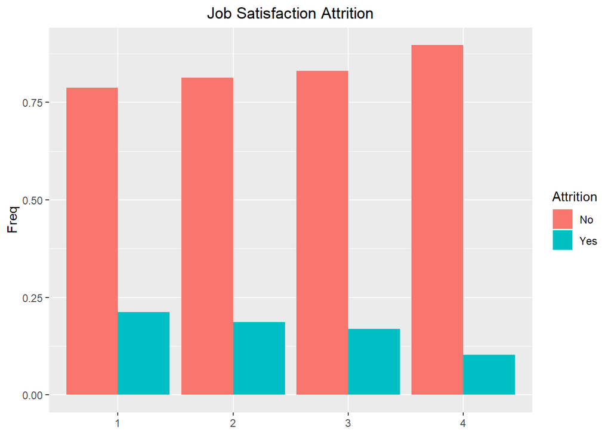

```r
ggplot(data=JobSatAttr_Prop, aes(x=Var1, y=Freq, fill=Var2)) +
  geom_bar(stat="identity", position=position_dodge()) +
  theme (axis.title.x = element_blank(), plot.title = element_text(hjust = 0.5)) +
  labs(fill = "Attrition") +
  ggtitle("Job Satisfaction Attrition")
```

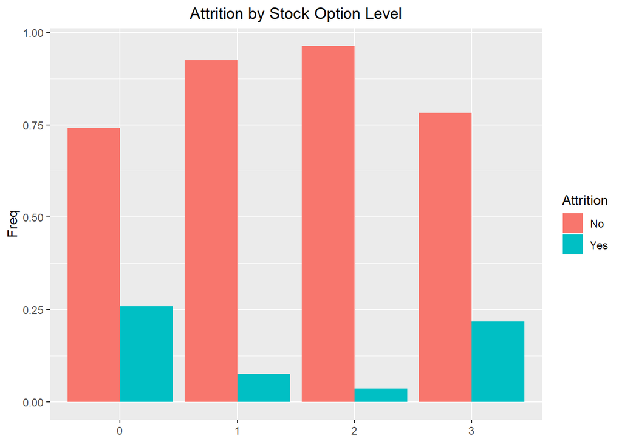

```r
ggplot(data=StockAttr_Prop, aes(x=Var1, y=Freq, fill=Var2)) +
  geom_bar(stat="identity", position=position_dodge()) +
  theme (axis.title.x = element_blank(), plot.title = element_text(hjust = 0.5)) +
  labs(fill = "Attrition") +
  ggtitle("Attrition by Stock Option Level")
```

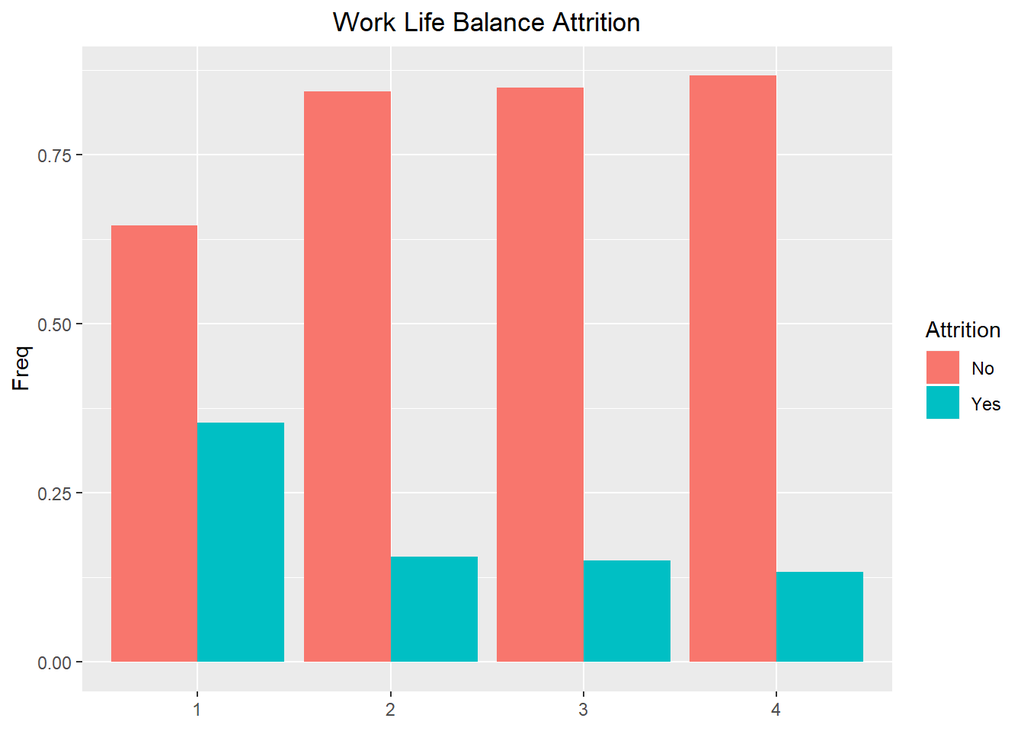

```r
ggplot(data=WorkLifeAttr_Prop, aes(x=Var1, y=Freq, fill=Var2)) +
  geom_bar(stat="identity", position=position_dodge()) +
  theme (axis.title.x = element_blank(), plot.title = element_text(hjust = 0.5)) +
  labs(fill = "Attrition") +
  ggtitle("Work Life Balance Attrition")
```

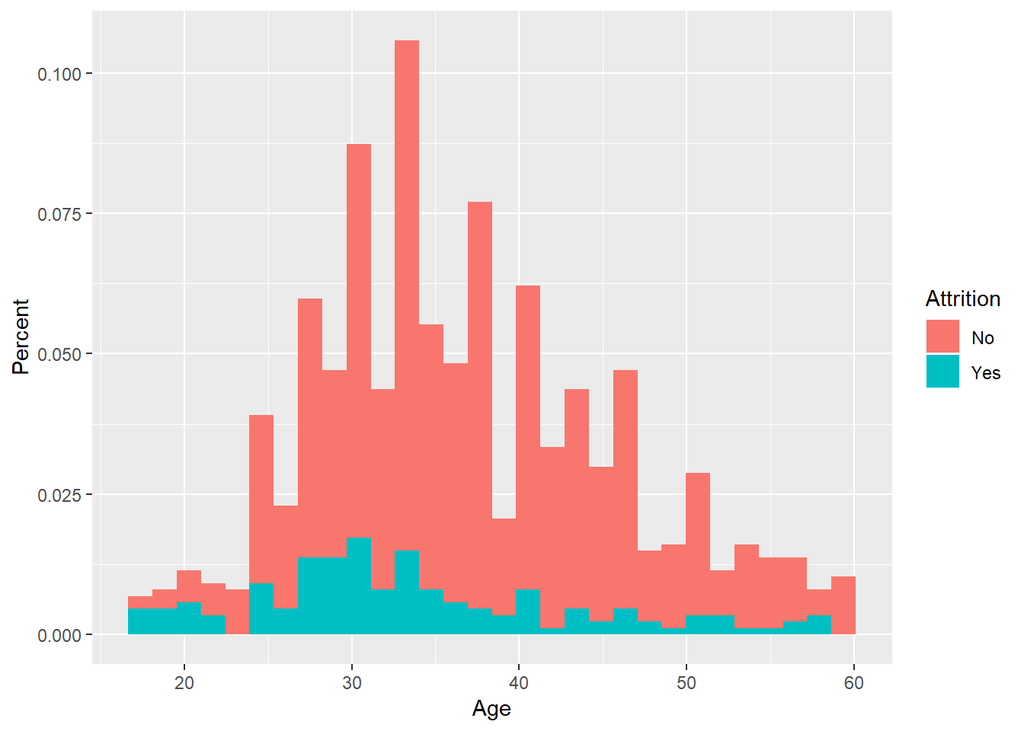

```r
#Plotting Continuous Variable Variance by Attrition
ggplot(data=EmpInfo2, aes(x=Age, fill=Attrition)) + ylab("Percent") +
  geom_histogram(aes(y=(..count..)/sum(..count..)))
```

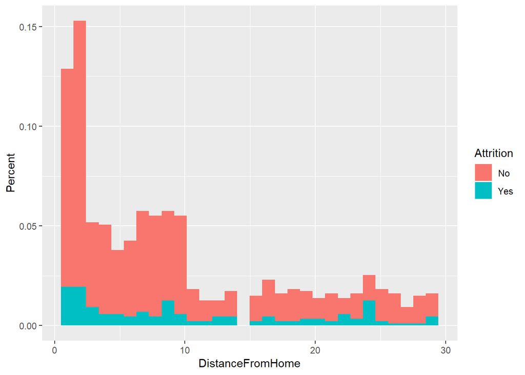

```r
ggplot(data=EmpInfo2, aes(x=DistanceFromHome, fill=Attrition)) + ylab("Percent") +
  geom_histogram(aes(y=(..count..)/sum(..count..)))
```

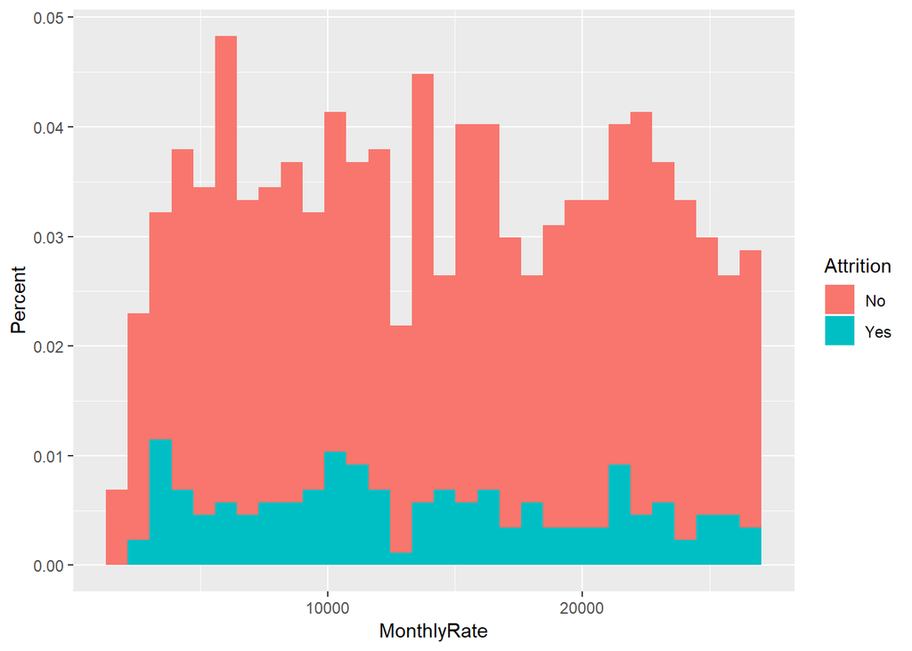

```r
ggplot(data=EmpInfo2, aes(x=MonthlyRate, fill=Attrition)) + ylab("Percent") +
  geom_histogram(aes(y=(..count..)/sum(..count..)))
```

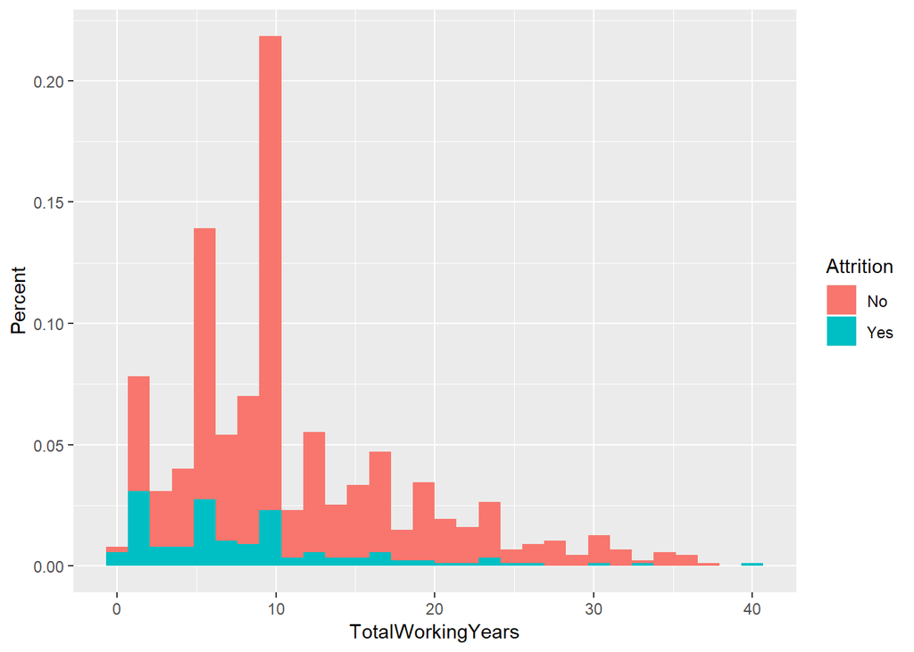

```r
ggplot(data=EmpInfo2, aes(x=TotalWorkingYears, fill=Attrition)) + ylab("Percent") +
  geom_histogram(aes(y=(..count..)/sum(..count..)))
```

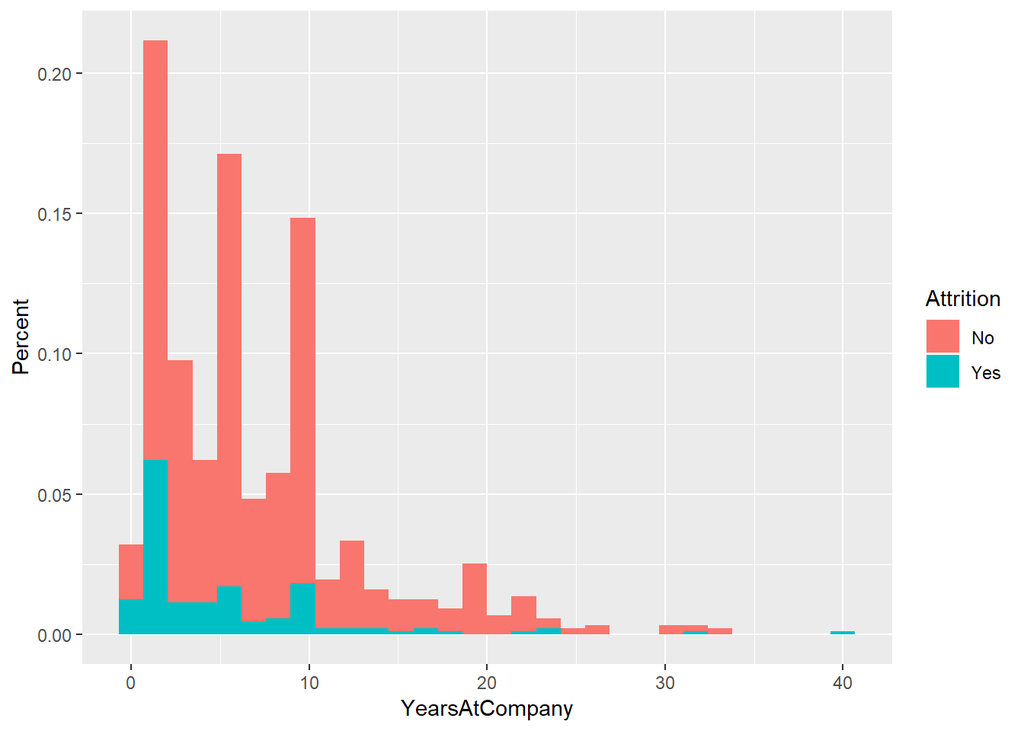

```r
ggplot(data=EmpInfo2, aes(x=YearsAtCompany, fill=Attrition)) + ylab("Percent") +
  geom_histogram(aes(y=(..count..)/sum(..count..)))
```

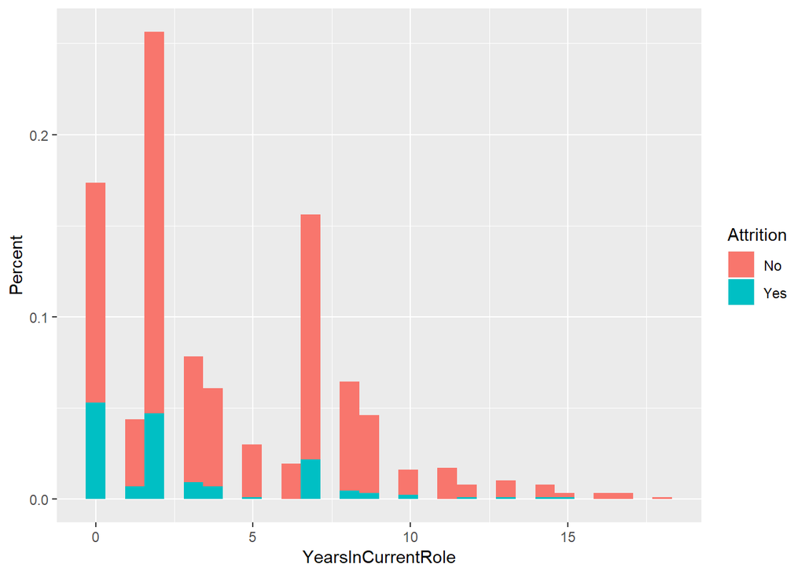

```r
ggplot(data=EmpInfo2, aes(x=YearsInCurrentRole, fill=Attrition)) + ylab("Percent") +
  geom_histogram(aes(y=(..count..)/sum(..count..)))
```

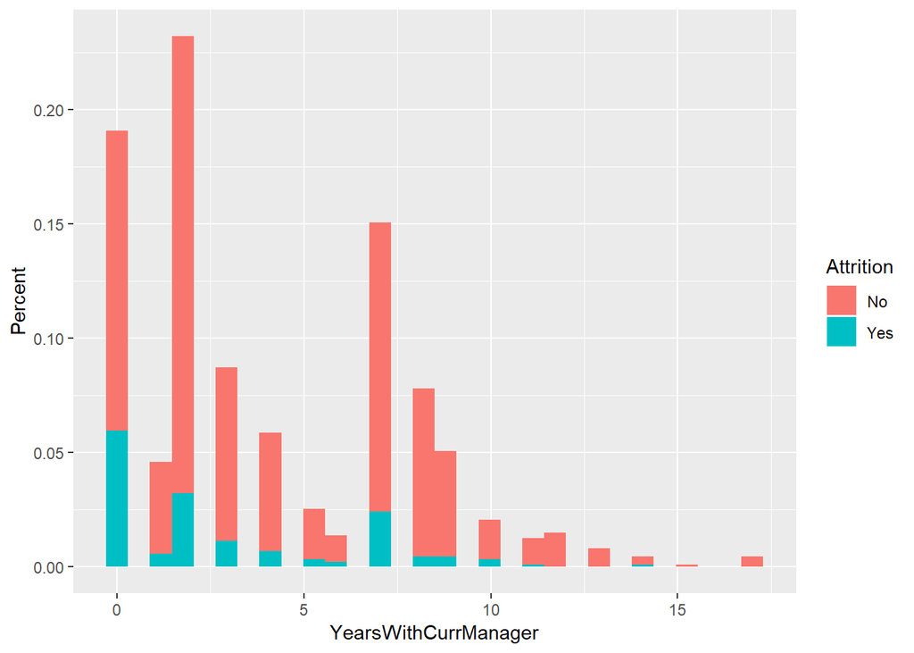

```r
ggplot(data=EmpInfo2, aes(x=YearsWithCurrManager, fill=Attrition)) + ylab("Percent") +
  geom_histogram(aes(y=(..count..)/sum(..count..)))
```

#### Observations

- The attrition rate appears to increase the more an employee feels they have to travel
- The Sales department has the highest attrition rate (21.6%) followed by HR (17.1%) and R&D (13.3%).
- Within these departments, Managers and Directors have the lowest attrition rates.
- This is inline with the overtime attrition rates as employees who work overtime (non-expempt) have a higher attrition rate of 31.2% compared to 9.7% for those who are salaried (typicaly upper level management).
- Attrition is also highest for employees in lower job levels.
- Oddly, attrition rates are highest with employees who either have the highest (21.8%) or lowest (25.9%) stock options available (levels 0 and 3), with the middle levels both having attrition rates less than 10%.
- Interestingly Divorces employees have the lowest attrition rate at 6.2%, whereas 26% of employees who are single do not choose to stay with the company.
- An employee’s environment only appears to increase attrition when rated as most unsatisfactory. This trend also applys to employees who feel like they have a poor work life balance.
- Attrition also appears to increase as Job Involvement Increases (assuming scores range from 1 as little to no involvement to 4 as High Involvement) and decrease as Job Satisfaction increases.

## Classifing Attrition: Naive Bayes Model

```r
#Referenced https://rpubs.com/riazakhan94/naive_bayes_classifier_e1071
library(caret)
#Partitioning Dataset
set.seed(7)
trainIndex <- createDataPartition(EmpInfo2$Attrition, p=0.7)$Resample1
train <- EmpInfo2[trainIndex, ]
test <- EmpInfo2[-trainIndex, ]

#Checking Totals
print(table(EmpInfo2$Attrition))
```

```
##
##  No Yes
## 730 140
```

```r
print(table(train$Attrition))
```

```
##
##  No Yes
## 511  98
```

```r
#Creating Classifier
library(e1071)
printALL <- function(model){
  trainPred <- predict(model, newdata = train, type = "class")
  trainTable <- table(train$Attrition, trainPred)
  testPred <- predict(Classifier_Model, newdata=test, type="class")
  testTable <- table(test$Attrition, testPred)
  trainAcc <- (trainTable[1,1]+trainTable[2,2])/sum(trainTable)
  testAcc <- (testTable[1,1]+testTable[2,2])/sum(testTable)
  message("Contingency Table for Training Data")
  print(trainTable)
  message("Contingency Table for Test Data")
  print(testTable)
  message("Accuracy")
  print(round(cbind(trainAccuracy=trainAcc, testAccuracy=testAcc),3))
  message("Training Sensitivity") #Need at least 0.6
  print(trainTable[1,1]/(trainTable[1,1]+trainTable[2,1]))
  message("Test Sensitivity") #Need at least 0.6
  print(testTable[1,1]/(testTable[1,1]+testTable[2,1]))
  message("Training Specificity") #Need at least 0.6
  print(trainTable[2,2]/(trainTable[1,2]+trainTable[2,2]))
  message("Test Specificity") #Need at least 0.6
  print(testTable[2,2]/(testTable[1,2]+testTable[2,2]))
}

#Building Classifier Models
#All in Model
NB_Classfier1 <- naiveBayes(Attrition~., data=train)
print(NB_Classfier1)
```

```
##
## Naive Bayes Classifier for Discrete Predictors
##
## Call:
## naiveBayes.default(x = X, y = Y, laplace = laplace)
##
## A-priori probabilities:
## Y
##        No       Yes
## 0.8390805 0.1609195
##
## Conditional probabilities:
##      ID
## Y         [,1]     [,2]
##   No  429.9432 248.8201
##   Yes 467.3265 248.7405
##
##      Age
## Y         [,1]     [,2]
##   No  37.24658 8.472439
##   Yes 34.56122 9.487992
##
##      BusinessTravel
## Y     Non-Travel Travel_Frequently Travel_Rarely
##   No  0.10567515        0.16438356    0.72994129
##   Yes 0.09183673        0.23469388    0.67346939
##
##      DailyRate
## Y         [,1]     [,2]
##   No  823.8434 393.6698
##   Yes 772.4082 400.1062
##
##      Department
## Y     Human Resources Research & Development      Sales
##   No       0.03522505             0.69667319 0.26810176
##   Yes      0.03061224             0.60204082 0.36734694
##
##      DistanceFromHome
## Y          [,1]     [,2]
##   No   9.154599 8.080573
```

[output cut: 137 more lines]

```
##
##      YearsSinceLastPromotion
## Y         [,1]     [,2]
##   No  2.144814 3.103219
##   Yes 2.224490 3.576932
##
##      YearsWithCurrManager
## Y         [,1]     [,2]
##   No  4.326810 3.613814
##   Yes 2.857143 3.119609
##
##      Rand
## Y           [,1]      [,2]
##   No  -0.4600365 0.7373596
##   Yes -0.3412103 0.6779339
```

```r
Classifier_Model <- NB_Classfier1 #Change for each new model
printALL(Classifier_Model)
```

```
## Contingency Table for Training Data
```

```
##      trainPred
##        No Yes
##   No  456  55
##   Yes  36  62
```

```
## Contingency Table for Test Data
```

```
##      testPred
##        No Yes
##   No  196  23
##   Yes  17  25
```

```
## Accuracy
```

```
##      trainAccuracy testAccuracy
## [1,]         0.851        0.847
```

```
## Training Sensitivity
```

```
## [1] 0.9268293
```

```
## Test Sensitivity
```

```
## [1] 0.9201878
```

```
## Training Specificity
```

```
## [1] 0.5299145
```

```
## Test Specificity
```

```
## [1] 0.5208333
```

```r
#Model2
#Removing DailyRate, Department, Gender, PerformanceRating, RelationshipSatisfaction due to low variance.
#Removing Age, MonthlyRate, TotalWorkingYears due to high correlation with mulitple other variables
NB_Classfier2 <- naiveBayes(Attrition~BusinessTravel+ DistanceFromHome+ Education+ EducationField+ EnvironmentSatisfaction+ HourlyRate+ JobInvolvement+ JobLevel+ JobRole+ JobSatisfaction+ MaritalStatus+ MonthlyIncome+ NumCompaniesWorked+ OverTime+ PercentSalaryHike+ StockOptionLevel+ TrainingTimesLastYear+ WorkLifeBalance+ YearsAtCompany+ YearsInCurrentRole+ YearsSinceLastPromotion+ YearsWithCurrManager, data=train)
print(NB_Classfier2)
```

```
##
## Naive Bayes Classifier for Discrete Predictors
##
## Call:
## naiveBayes.default(x = X, y = Y, laplace = laplace)
##
## A-priori probabilities:
## Y
##        No       Yes
## 0.8390805 0.1609195
##
## Conditional probabilities:
##      BusinessTravel
## Y     Non-Travel Travel_Frequently Travel_Rarely
##   No  0.10567515        0.16438356    0.72994129
##   Yes 0.09183673        0.23469388    0.67346939
##
##      DistanceFromHome
## Y          [,1]     [,2]
##   No   9.154599 8.080573
##   Yes 11.489796 8.781711
##
##      Education
## Y              1          2          3          4          5
##   No  0.10371820 0.20743640 0.39138943 0.26614481 0.03131115
##   Yes 0.14285714 0.21428571 0.37755102 0.26530612 0.00000000
##
##      EducationField
## Y     Human Resources Life Sciences  Marketing    Medical      Other
##   No       0.01174168    0.41878669 0.09589041 0.34050881 0.05479452
##   Yes      0.02040816    0.38775510 0.10204082 0.29591837 0.08163265
##      EducationField
## Y     Technical Degree
##   No        0.07827789
##   Yes       0.11224490
##
##      EnvironmentSatisfaction
## Y             1         2         3         4
##   No  0.1976517 0.2191781 0.2759295 0.3072407
##   Yes 0.2755102 0.1530612 0.2857143 0.2857143
```

[output cut: 82 more lines]

```
##
##      YearsInCurrentRole
## Y         [,1]     [,2]
##   No  4.275930 3.548569
##   Yes 2.785714 3.127035
##
##      YearsSinceLastPromotion
## Y         [,1]     [,2]
##   No  2.144814 3.103219
##   Yes 2.224490 3.576932
##
##      YearsWithCurrManager
## Y         [,1]     [,2]
##   No  4.326810 3.613814
##   Yes 2.857143 3.119609
```

```r
Classifier_Model <- NB_Classfier2 #Change for each new model
printALL(Classifier_Model)
```

```
## Contingency Table for Training Data
```

```
##      trainPred
##        No Yes
##   No  464  47
##   Yes  38  60
```

```
## Contingency Table for Test Data
```

```
##      testPred
##        No Yes
##   No  204  15
##   Yes  18  24
```

```
## Accuracy
```

```
##      trainAccuracy testAccuracy
## [1,]          0.86        0.874
```

```
## Training Sensitivity
```

```
## [1] 0.9243028
```

```
## Test Sensitivity
```

```
## [1] 0.9189189
```

```
## Training Specificity
```

```
## [1] 0.5607477
```

```
## Test Specificity
```

```
## [1] 0.6153846
```

```r
#Model3
#Adding All Variables with Significant Difference in Attrition
NB_Classfier3 <- naiveBayes(Attrition~BusinessTravel + Department + JobRole + MaritalStatus + OverTime + EnvironmentSatisfaction + JobInvolvement + JobLevel + JobSatisfaction + StockOptionLevel + WorkLifeBalance + Age + DistanceFromHome + TotalWorkingYears + YearsAtCompany + YearsInCurrentRole, data=train)
print(NB_Classfier3)
```

```
##
## Naive Bayes Classifier for Discrete Predictors
##
## Call:
## naiveBayes.default(x = X, y = Y, laplace = laplace)
##
## A-priori probabilities:
## Y
##        No       Yes
## 0.8390805 0.1609195
##
## Conditional probabilities:
##      BusinessTravel
## Y     Non-Travel Travel_Frequently Travel_Rarely
##   No  0.10567515        0.16438356    0.72994129
##   Yes 0.09183673        0.23469388    0.67346939
##
##      Department
## Y     Human Resources Research & Development      Sales
##   No       0.03522505             0.69667319 0.26810176
##   Yes      0.03061224             0.60204082 0.36734694
##
##      JobRole
## Y     Healthcare Representative Human Resources Laboratory Technician
##   No                 0.09784736      0.02935421            0.17416830
##   Yes                0.07142857      0.03061224            0.23469388
##      JobRole
## Y        Manager Manufacturing Director Research Director
##   No  0.05283757             0.12720157        0.07436399
##   Yes 0.03061224             0.02040816        0.01020408
##      JobRole
## Y     Research Scientist Sales Executive Sales Representative
##   No          0.19960861      0.20939335           0.03522505
##   Yes         0.24489796      0.24489796           0.11224490
##
##      MaritalStatus
## Y       Divorced    Married     Single
##   No  0.23483366 0.48532290 0.27984344
##   Yes 0.09183673 0.43877551 0.46938776
##
```

[output cut: 44 more lines]

```
##
##      TotalWorkingYears
## Y          [,1]     [,2]
##   No  11.538160 7.183178
##   Yes  8.346939 7.124955
##
##      YearsAtCompany
## Y         [,1]     [,2]
##   No  7.203523 5.880649
##   Yes 5.122449 6.169872
##
##      YearsInCurrentRole
## Y         [,1]     [,2]
##   No  4.275930 3.548569
##   Yes 2.785714 3.127035
```

```r
Classifier_Model <- NB_Classfier3 #Change for each new model
printALL(Classifier_Model)
```

```
## Contingency Table for Training Data
```

```
##      trainPred
##        No Yes
##   No  466  45
##   Yes  42  56
```

```
## Contingency Table for Test Data
```

```
##      testPred
##        No Yes
##   No  207  12
##   Yes  18  24
```

```
## Accuracy
```

```
##      trainAccuracy testAccuracy
## [1,]         0.857        0.885
```

```
## Training Sensitivity
```

```
## [1] 0.9173228
```

```
## Test Sensitivity
```

```
## [1] 0.92
```

```
## Training Specificity
```

```
## [1] 0.5544554
```

```
## Test Specificity
```

```
## [1] 0.6666667
```

```r
#Model4
#Adding All Variables with Significant Difference in Attrition
#But, removing TotalWorkingYears and YearsAtCompany as they are both highly correlated with each other and can possibly be explained by Age and YearsInCurrentRole
NB_Classfier4 <- naiveBayes(Attrition~BusinessTravel + Department + JobRole + MaritalStatus + OverTime + EnvironmentSatisfaction + JobInvolvement + JobLevel + JobSatisfaction + StockOptionLevel + WorkLifeBalance + Age + DistanceFromHome  + YearsInCurrentRole, data=train)
print(NB_Classfier4)
```

```
##
## Naive Bayes Classifier for Discrete Predictors
##
## Call:
## naiveBayes.default(x = X, y = Y, laplace = laplace)
##
## A-priori probabilities:
## Y
##        No       Yes
## 0.8390805 0.1609195
##
## Conditional probabilities:
##      BusinessTravel
## Y     Non-Travel Travel_Frequently Travel_Rarely
##   No  0.10567515        0.16438356    0.72994129
##   Yes 0.09183673        0.23469388    0.67346939
##
##      Department
## Y     Human Resources Research & Development      Sales
##   No       0.03522505             0.69667319 0.26810176
##   Yes      0.03061224             0.60204082 0.36734694
##
##      JobRole
## Y     Healthcare Representative Human Resources Laboratory Technician
##   No                 0.09784736      0.02935421            0.17416830
##   Yes                0.07142857      0.03061224            0.23469388
##      JobRole
## Y        Manager Manufacturing Director Research Director
##   No  0.05283757             0.12720157        0.07436399
##   Yes 0.03061224             0.02040816        0.01020408
##      JobRole
## Y     Research Scientist Sales Executive Sales Representative
##   No          0.19960861      0.20939335           0.03522505
##   Yes         0.24489796      0.24489796           0.11224490
##
##      MaritalStatus
## Y       Divorced    Married     Single
##   No  0.23483366 0.48532290 0.27984344
##   Yes 0.09183673 0.43877551 0.46938776
##
```

[output cut: 34 more lines]

```
##
##      Age
## Y         [,1]     [,2]
##   No  37.24658 8.472439
##   Yes 34.56122 9.487992
##
##      DistanceFromHome
## Y          [,1]     [,2]
##   No   9.154599 8.080573
##   Yes 11.489796 8.781711
##
##      YearsInCurrentRole
## Y         [,1]     [,2]
##   No  4.275930 3.548569
##   Yes 2.785714 3.127035
```

```r
Classifier_Model <- NB_Classfier4 #Change for each new model
printALL(Classifier_Model)
```

```
## Contingency Table for Training Data
```

```
##      trainPred
##        No Yes
##   No  482  29
##   Yes  46  52
```

```
## Contingency Table for Test Data
```

```
##      testPred
##        No Yes
##   No  211   8
##   Yes  20  22
```

```
## Accuracy
```

```
##      trainAccuracy testAccuracy
## [1,]         0.877        0.893
```

```
## Training Sensitivity
```

```
## [1] 0.9128788
```

```
## Test Sensitivity
```

```
## [1] 0.9134199
```

```
## Training Specificity
```

```
## [1] 0.6419753
```

```
## Test Specificity
```

```
## [1] 0.7333333
```

## Predicting Attrition for Validation Dataset

```r
#Predicting Attrition for Validation Data
Predicted_Attr <- predict(Classifier_Model,newdata = Attr_Validation,type = 'class')
Attr_Validation$Attrition <- Predicted_Attr
head(Attr_Validation)
```

```
##     ID Age    BusinessTravel DailyRate             Department
## 1 1171  35     Travel_Rarely       750 Research & Development
## 2 1172  33     Travel_Rarely       147        Human Resources
## 3 1173  26     Travel_Rarely      1330 Research & Development
## 4 1174  55     Travel_Rarely      1311 Research & Development
## 5 1175  29     Travel_Rarely      1246                  Sales
## 6 1176  51 Travel_Frequently      1456 Research & Development
##   DistanceFromHome Education  EducationField EmployeeNumber
## 1               28         3   Life Sciences           1596
## 2                2         3 Human Resources           1207
## 3               21         3         Medical           1107
## 4                2         3   Life Sciences            505
## 5               19         3   Life Sciences           1497
## 6                1         4         Medical            145
##   EnvironmentSatisfaction Gender HourlyRate JobInvolvement JobLevel
```

[output cut: 48 more lines]

```r
dim(Attr_Validation)
```

```
## [1] 300  34
```

```r
#Exporting Results to .csv
# write.csv(Attr_Validation[,c(1,34)],"Prediction Files/Case2PredictionsColeman Attrition.csv")
```

## Linear Regression: Predicting Montly Income

```r
#Referencing http://www.sthda.com/english/articles/37-model-selection-essentials-in-r/154-stepwise-regression-essentials-in-r/
library(caret)
library(leaps)
#Fit full linear model
LinearModel <- lm(MonthlyIncome ~ ., train)
summary(LinearModel)
```

```
##
## Call:
## lm(formula = MonthlyIncome ~ ., data = train)
##
## Residuals:
##     Min      1Q  Median      3Q     Max
## -3293.5  -612.9   -85.1   588.8  3869.2
##
## Coefficients:
##                                    Estimate Std. Error t value Pr(>|t|)
## (Intercept)                       2.712e+03  1.010e+03   2.685 0.007476
## ID                                4.635e-01  5.217e-01   0.888 0.374674
## Age                               4.481e-01  6.749e+00   0.066 0.947087
## AttritionYes                     -1.137e+01  1.399e+02  -0.081 0.935268
## BusinessTravelTravel_Frequently   1.424e+02  1.726e+02   0.825 0.409762
## BusinessTravelTravel_Rarely       3.543e+02  1.454e+02   2.437 0.015124
## DailyRate                         2.058e-01  1.107e-01   1.859 0.063591
## DepartmentResearch & Development  8.164e+01  6.940e+02   0.118 0.906400
## DepartmentSales                  -7.091e+02  7.093e+02  -1.000 0.317874
## DistanceFromHome                 -4.183e+00  5.390e+00  -0.776 0.438054
## Education2                       -1.265e+01  1.605e+02  -0.079 0.937218
## Education3                       -4.615e+01  1.466e+02  -0.315 0.753007
## Education4                        2.197e+02  1.599e+02   1.374 0.169939
## Education5                       -5.546e+02  3.022e+02  -1.836 0.066978
## EducationFieldLife Sciences      -5.527e+01  4.751e+02  -0.116 0.907423
## EducationFieldMarketing          -1.101e+02  5.016e+02  -0.220 0.826340
## EducationFieldMedical            -1.556e+02  4.741e+02  -0.328 0.742889
## EducationFieldOther              -2.649e+02  5.003e+02  -0.529 0.596744
## EducationFieldTechnical Degree   -2.047e+02  4.858e+02  -0.421 0.673752
## EmployeeNumber                    3.738e-02  7.183e-02   0.520 0.603037
## EnvironmentSatisfaction2          9.801e-01  1.319e+02   0.007 0.994072
## EnvironmentSatisfaction3         -8.308e+01  1.245e+02  -0.667 0.504810
## EnvironmentSatisfaction4         -1.343e+02  1.209e+02  -1.111 0.267273
## GenderMale                        5.563e+01  8.856e+01   0.628 0.530162
## HourlyRate                       -1.173e+00  2.191e+00  -0.535 0.592738
## JobInvolvement2                  -8.468e+01  2.005e+02  -0.422 0.673010
## JobInvolvement3                  -8.951e+01  1.937e+02  -0.462 0.644173
## JobInvolvement4                  -7.685e+01  2.349e+02  -0.327 0.743698
## JobLevel2                         1.708e+03  1.757e+02   9.725  < 2e-16
## JobLevel3                         5.077e+03  2.319e+02  21.894  < 2e-16
```

[output cut: 104 more lines]

```
## TrainingTimesLastYear6
## WorkLifeBalance2
## WorkLifeBalance3
## WorkLifeBalance4
## YearsAtCompany
## YearsInCurrentRole
## YearsSinceLastPromotion
## YearsWithCurrManager
## Rand
## ---
## Signif. codes:  0 '***' 0.001 '**' 0.01 '*' 0.05 '.' 0.1 ' ' 1
##
## Residual standard error: 1008 on 538 degrees of freedom
## Multiple R-squared:  0.9548, Adjusted R-squared:  0.9489
## F-statistic: 162.4 on 70 and 538 DF,  p-value: < 2.2e-16
```

```r
#Model Selction: Forward, Backward, Stepwise
TrainControl <- trainControl(method = "cv", number = 10)

# Backward Selection
BackwardModel <- train(MonthlyIncome ~., data = train, method = "leapBackward", trControl = TrainControl)
BackwardModel$results #includes RMSE
```

```
##   nvmax     RMSE  Rsquared       MAE   RMSESD RsquaredSD     MAESD
## 1     2 2755.558 0.5935356 2179.6104 191.3427 0.13021621 177.12506
## 2     3 1742.874 0.8423952 1456.4225 113.7943 0.03605365  75.69176
## 3     4 1281.254 0.9172724  955.7802 152.0037 0.01588401  99.49035
```

```r
BackwardPredict <- predict(BackwardModel, newdata = test)
test$BackwardPredict <- BackwardPredict

# Forward Selection
ForwardModel <- train(MonthlyIncome ~., data = train, method = "leapForward", trControl = TrainControl)
ForwardModel$results #includes RMSE
```

```
##   nvmax     RMSE  Rsquared      MAE   RMSESD RsquaredSD    MAESD
## 1     2 2671.536 0.6386662 1982.564 270.2486 0.08401915 127.9767
## 2     3 2309.822 0.7210108 1763.525 392.1121 0.11152848 166.0191
## 3     4 1894.714 0.8195423 1476.311 190.3066 0.05431099 126.3857
```

```r
ForwardPredict <- predict(ForwardModel, newdata = test)
test$ForwardPredict <- ForwardPredict

# Stepwise Selection
StepwiseModel <- train(MonthlyIncome ~., data = train, method = "leapSeq", trControl = TrainControl)
StepwiseModel$results #includes RMSE
```

```
##   nvmax     RMSE  Rsquared      MAE   RMSESD RsquaredSD    MAESD
## 1     2 2651.919 0.6469918 1979.660 216.4414 0.06923203 170.7163
## 2     3 2117.286 0.7695170 1696.602 237.6506 0.06718374 196.6067
## 3     4 1865.042 0.8241248 1447.071 333.8167 0.05896186 266.0574
```

```r
StepwisePredict <- predict(StepwiseModel, newdata = test)
test$StepwisePredict <- StepwisePredict


#Calculating ASE stats for each model
ASEholderForward = c()
ASEholderBackward = c()
ASEholderStepwise = c()

ASEholderForward = sum((test$ForwardPredict - test$MonthlyIncome)^2)/length(test$MonthlyIncome)
ASEholderBackward = sum((test$BackwardPredict - test$MonthlyIncome)^2)/length(test$MonthlyIncome)
ASEholderStepwise = sum((test$StepwisePredict - test$MonthlyIncome)^2)/length(test$MonthlyIncome)

#ASE Stats
ASEholderForward
```

```
## [1] 3585525
```

```r
ASEholderBackward
```

```
## [1] 1470375
```

```r
ASEholderStepwise
```

```
## [1] 3585525
```

```r
#RMSE Stats
BackwardModel$results
```

```
##   nvmax     RMSE  Rsquared       MAE   RMSESD RsquaredSD     MAESD
## 1     2 2755.558 0.5935356 2179.6104 191.3427 0.13021621 177.12506
## 2     3 1742.874 0.8423952 1456.4225 113.7943 0.03605365  75.69176
## 3     4 1281.254 0.9172724  955.7802 152.0037 0.01588401  99.49035
```

```r
ForwardModel$results
```

```
##   nvmax     RMSE  Rsquared      MAE   RMSESD RsquaredSD    MAESD
## 1     2 2671.536 0.6386662 1982.564 270.2486 0.08401915 127.9767
## 2     3 2309.822 0.7210108 1763.525 392.1121 0.11152848 166.0191
## 3     4 1894.714 0.8195423 1476.311 190.3066 0.05431099 126.3857
```

```r
StepwiseModel$results
```

```
##   nvmax     RMSE  Rsquared      MAE   RMSESD RsquaredSD    MAESD
## 1     2 2651.919 0.6469918 1979.660 216.4414 0.06923203 170.7163
## 2     3 2117.286 0.7695170 1696.602 237.6506 0.06718374 196.6067
## 3     4 1865.042 0.8241248 1447.071 333.8167 0.05896186 266.0574
```

#### Backward Selection has lowest RMSE and ASE and will be used on the Validation Dataset.

## Predicting Montly Income for Validation Dataset

```r
#Predicting Income for Validation Data
Final_Predictions <- predict(BackwardModel, newdata = Income_Predict)
Income_Predict$MonthlyIncome <- Final_Predictions
head(Income_Predict)
```

```
##    ID Age Attrition    BusinessTravel DailyRate             Department
## 1 871  43        No Travel_Frequently      1422                  Sales
## 2 872  33        No     Travel_Rarely       461 Research & Development
## 3 873  55       Yes     Travel_Rarely       267                  Sales
## 4 874  36        No        Non-Travel      1351 Research & Development
## 5 875  27        No     Travel_Rarely      1302 Research & Development
## 6 876  39       Yes     Travel_Rarely       895                  Sales
##   DistanceFromHome Education   EducationField EmployeeNumber
## 1                2         4    Life Sciences           1849
## 2               13         1    Life Sciences            995
## 3               13         4        Marketing           1372
## 4                9         4    Life Sciences           1949
## 5               19         3            Other           1619
## 6                5         3 Technical Degree             42
##   EnvironmentSatisfaction Gender HourlyRate JobInvolvement JobLevel
```

[output cut: 41 more lines]

```r
dim(Income_Predict)
```

```
## [1] 300  34
```

```r
#Exporting Results to .csv
# write.csv(Income_Predict[,c(1,34)],"Prediction Files/Case2PredictionsColeman Salary.csv")
```